# 05 Converting to and from non-tidy formats

H. David Shea

04 Aug 2021

Here we look at converting between tidy text format and other common formats used in text and natural language processing.

## Tidying a document-term matrix

"One of the most common structures that text mining packages work with is the document-term matrix (or DTM). This is a matrix where:

- each row represents one document (such as a book or article),
- each column represents one term, and
- each value (typically) contains the number of appearances of that term in that document."

### Tidying DocumentTermMatrix objects

```r
data("AssociatedPress", package = "topicmodels")
AssociatedPress
```

```
#> <<DocumentTermMatrix (documents: 2246, terms: 10473)>>
#> Non-/sparse entries: 302031/23220327
#> Sparsity           : 99%
#> Maximal term length: 18
#> Weighting          : term frequency (tf)
```

```r
terms <- Terms(AssociatedPress)
head(terms)
```

```
#> [1] "aaron"      "abandon"    "abandoned"  "abandoning" "abbott"
#> [6] "abboud"
```

```r
ap_td <- tidy(AssociatedPress)
ap_td %>%
    slice_sample(n = 10) %>%
    kable(caption = "DTM converted to tidy data frame with `tidy()`.")
```

DTM converted to tidy data frame with `tidy()`.

| document | term | count |
| --- | --- | --- |
| 912 | contrast | 1 |
| 1169 | improve | 1 |
| 117 | lung | 1 |
| 344 | went | 1 |
| 2061 | indictment | 3 |
| 631 | listed | 1 |
| 1076 | official | 1 |
| 1097 | newspapers | 1 |
| 2200 | experts | 1 |
| 135 | scheduled | 1 |

```r
ap_sentiments <- ap_td %>%
    inner_join(get_sentiments("bing"), by = c("term" = "word"))

ap_sentiments %>%
    slice_sample(n = 10) %>%
    kable(caption = "Tidy formatted DTM joined with `bing` lexicon sentiment data")
```

Tidy formatted DTM joined with `bing` lexicon sentiment data

| document | term | count | sentiment |
| --- | --- | --- | --- |
| 2048 | delay | 1 | negative |
| 691 | contribution | 1 | positive |
| 234 | unconstitutional | 1 | negative |
| 1578 | right | 1 | positive |
| 1860 | honoring | 1 | positive |
| 1978 | vice | 2 | negative |
| 724 | negative | 1 | negative |
| 101 | stupid | 1 | negative |
| 1056 | illness | 1 | negative |
| 879 | issues | 7 | negative |

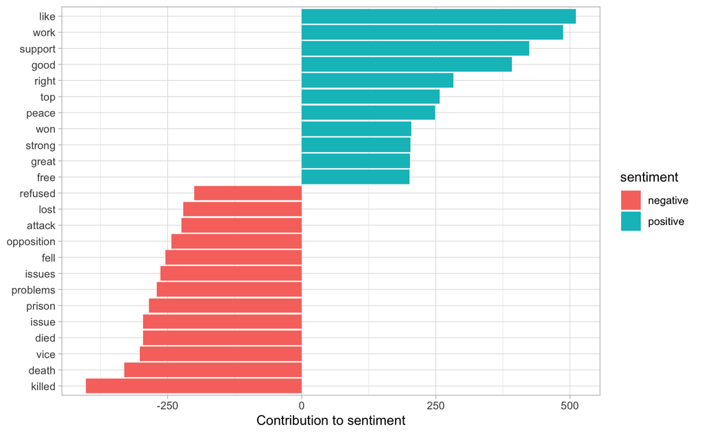

```r
ap_sentiments %>%
    count(sentiment, term, wt = count) %>%
    ungroup() %>%
    filter(n >= 200) %>%
    mutate(n = ifelse(sentiment == "negative",-n, n)) %>%
    mutate(term = reorder(term, n)) %>%
    ggplot(aes(n, term, fill = sentiment)) +
    geom_col() +
    labs(x = "Contribution to sentiment", y = NULL) +
    theme_light()
```

### Tidying `dfm` objects

`dfm` (document-feature matrix) is another common format for text and natural langauge processing - specifically from the `quanteda` package.

```r
data("data_corpus_inaugural", package = "quanteda")
inaug_dfm <- dfm(data_corpus_inaugural, verbose = FALSE)
inaug_dfm
```

```
#> Document-feature matrix of: 59 documents, 9,439 features (91.84% sparse) and 4 docvars.
#>                  features
#> docs              fellow-citizens  of the senate and house representatives :
#>   1789-Washington               1  71 116      1  48     2               2 1
#>   1793-Washington               0  11  13      0   2     0               0 1
#>   1797-Adams                    3 140 163      1 130     0               2 0
#>   1801-Jefferson                2 104 130      0  81     0               0 1
#>   1805-Jefferson                0 101 143      0  93     0               0 0
#>   1809-Madison                  1  69 104      0  43     0               0 0
#>                  features
#> docs              among vicissitudes
#>   1789-Washington     1            1
#>   1793-Washington     0            0
#>   1797-Adams          4            0
#>   1801-Jefferson      1            0
#>   1805-Jefferson      7            0
#>   1809-Madison        0            0
#> [ reached max_ndoc ... 53 more documents, reached max_nfeat ... 9,429 more features ]
```

```r
inaug_td <- tidy(inaug_dfm)
inaug_td %>%
    slice_sample(n = 10) %>%
    kable(caption = "`dfm` object containing US President inagural speechees converted to tidy format with `tidy()`.")
```

`dfm` object containing US President inagural speechees converted to tidy format with `tidy()`.

| document | term | count |
| --- | --- | --- |
| 1929-Hoover | west | 1 |
| 1957-Eisenhower | seal | 1 |
| 1837-VanBuren | similar | 1 |
| 1853-Pierce | repose | 1 |
| 1825-Adams | solemnities | 1 |
| 1961-Kennedy | against | 2 |
| 1929-Hoover | fields | 2 |
| 1789-Washington | resorting | 1 |
| 1921-Harding | intelligent | 1 |
| 1981-Reagan | unique | 1 |

```r
inaug_tf_idf <- inaug_td %>%
    bind_tf_idf(term, document, count) %>%
    arrange(desc(tf_idf))

inaug_tf_idf %>%
    slice_max(tf_idf, n = 10) %>%
    kable(caption = "Highest `tf-idf` values for terms by each US Presidential inauguration speech.")
```

| document | term | count | tf | idf | tf_idf |
| --- | --- | --- | --- | --- | --- |
| 1793-Washington | arrive | 1 | 0.0068027 | 4.077537 | 0.0277383 |
| 1793-Washington | upbraidings | 1 | 0.0068027 | 4.077537 | 0.0277383 |
| 1793-Washington | violated | 1 | 0.0068027 | 3.384390 | 0.0230231 |
| 1793-Washington | willingly | 1 | 0.0068027 | 3.384390 | 0.0230231 |
| 1793-Washington | incurring | 1 | 0.0068027 | 3.384390 | 0.0230231 |
| 1793-Washington | previous | 1 | 0.0068027 | 2.978925 | 0.0202648 |
| 1793-Washington | knowingly | 1 | 0.0068027 | 2.978925 | 0.0202648 |
| 1793-Washington | injunctions | 1 | 0.0068027 | 2.978925 | 0.0202648 |
| 1793-Washington | witnesses | 1 | 0.0068027 | 2.978925 | 0.0202648 |
| 1793-Washington | besides | 1 | 0.0068027 | 2.691243 | 0.0183078 |

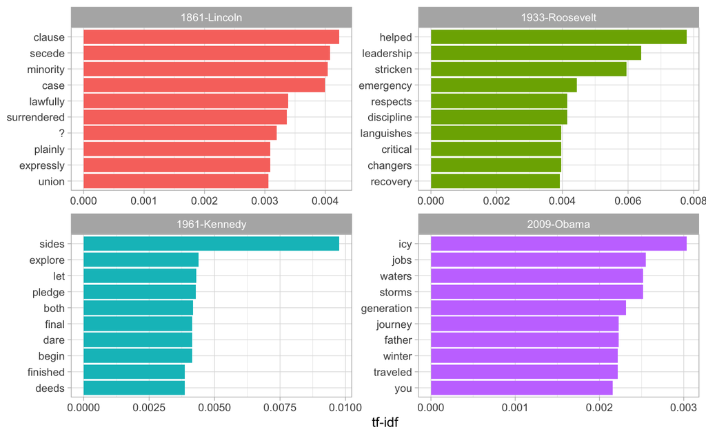

The terms with the highest `tf-idf` from each of four selected inaugural addresses.

```r
speeches <- c("1933-Roosevelt",
              "1861-Lincoln",
              "1961-Kennedy",
              "2009-Obama")

inaug_tf_idf %>%
    filter(document %in% speeches) %>%
    group_by(document) %>%
    slice_max(tf_idf, n = 10, with_ties = FALSE) %>%
    ungroup() %>%
    mutate(term = reorder_within(term, tf_idf, document)) %>%
    ggplot(aes(term, tf_idf, fill = document)) +
    geom_col(show.legend = FALSE) +
    facet_wrap( ~ document, scales = "free") +
    coord_flip() +
    scale_x_reordered() +
    labs(x = NULL,
         y = "tf-idf") +
    theme_light()
```

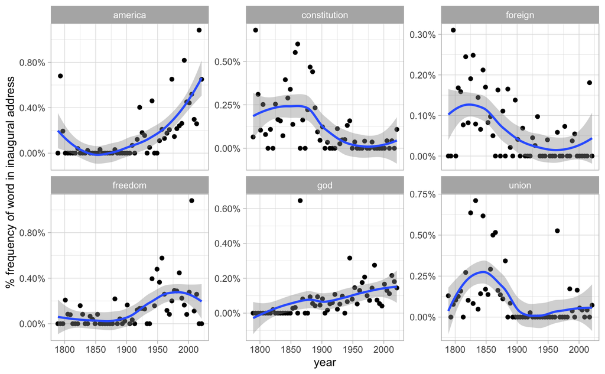

Changes in word frequency over time within Presidential inaugural addresses, for six selected terms

```r
year_term_counts <- inaug_td %>%
    extract(document, "year", "(\\d+)", convert = TRUE) %>%
    complete(year, term, fill = list(count = 0)) %>%
    group_by(year) %>%
    mutate(year_total = sum(count))

year_term_counts %>%
    filter(term %in% c("god", "america", "foreign", "union", "constitution", "freedom")) %>%
    ggplot(aes(year, count / year_total)) +
    geom_point() +
    geom_smooth() +
    facet_wrap( ~ term, scales = "free_y") +
    scale_y_continuous(labels = scales::percent_format()) +
    labs(y = "% frequency of word in inaugural address") +
    theme_light()
```

“These examples show how you can use tidytext, and the related suite of tidy tools, to analyze sources even if their origin was not in a tidy format.”

## Casting tidy text data into a matrix

There are three verbs provided in `tidytext` for converting from tidy format to the alternative formats discussed.

```r
ap_td %>%
    cast_dtm(document, term, count)
```

```
#> <<DocumentTermMatrix (documents: 2246, terms: 10473)>>
#> Non-/sparse entries: 302031/23220327
#> Sparsity           : 99%
#> Maximal term length: 18
#> Weighting          : term frequency (tf)
```

```r
ap_td %>%
    cast_dfm(document, term, count)
```

```
#> Document-feature matrix of: 2,246 documents, 10,473 features (98.72% sparse) and 0 docvars.
#>     features
#> docs adding adult ago alcohol allegedly allen apparently appeared arrested
#>    1      1     2   1       1         1     1          2        1        1
#>    2      0     0   0       0         0     0          0        1        0
#>    3      0     0   1       0         0     0          0        1        0
#>    4      0     0   3       0         0     0          0        0        0
#>    5      0     0   0       0         0     0          0        0        0
#>    6      0     0   2       0         0     0          0        0        0
#>     features
#> docs assault
#>    1       1
#>    2       0
#>    3       0
#>    4       0
#>    5       0
#>    6       0
#> [ reached max_ndoc ... 2,240 more documents, reached max_nfeat ... 10,463 more features ]
```

```r
m <- ap_td %>%
    cast_sparse(document, term, count)

class(m)
```

```
#> [1] "dgCMatrix"
#> attr(,"package")
#> [1] "Matrix"
```

```r
dim(m)
```

```
#> [1]  2246 10473
```

```r
austen_dtm <- austen_books() %>%
    unnest_tokens(word, text) %>%
    count(book, word) %>%
    cast_dtm(book, word, n)

austen_dtm
```

```
#> <<DocumentTermMatrix (documents: 6, terms: 14520)>>
#> Non-/sparse entries: 40379/46741
#> Sparsity           : 54%
#> Maximal term length: 19
#> Weighting          : term frequency (tf)
```

## Tidying corpus objects with metadata

Another common format for text is called a “corpus”. These store metadata along with text.

```r
data("acq")
acq
```

```
#> <<VCorpus>>
#> Metadata:  corpus specific: 0, document level (indexed): 0
#> Content:  documents: 50
```

```r
acq[[1]]
```

```
#> <<PlainTextDocument>>
#> Metadata:  15
#> Content:  chars: 1287
```

```r
acq_td <- tidy(acq)
acq_td
```

```
#> # A tibble: 50 x 16
#>    author  datetimestamp       description heading  id    language origin topics
#>    <chr>   <dttm>              <chr>       <chr>    <chr> <chr>    <chr>  <chr>
#>  1 <NA>    1987-02-26 15:18:06 ""          COMPUTE… 10    en       Reute… YES
#>  2 <NA>    1987-02-26 15:19:15 ""          OHIO MA… 12    en       Reute… YES
#>  3 <NA>    1987-02-26 15:49:56 ""          MCLEAN'… 44    en       Reute… YES
#>  4 By Cal… 1987-02-26 15:51:17 ""          CHEMLAW… 45    en       Reute… YES
#>  5 <NA>    1987-02-26 16:08:33 ""          <COFAB … 68    en       Reute… YES
#>  6 <NA>    1987-02-26 16:32:37 ""          INVESTM… 96    en       Reute… YES
#>  7 By Pat… 1987-02-26 16:43:13 ""          AMERICA… 110   en       Reute… YES
#>  8 <NA>    1987-02-26 16:59:25 ""          HONG KO… 125   en       Reute… YES
#>  9 <NA>    1987-02-26 17:01:28 ""          LIEBERT… 128   en       Reute… YES
#> 10 <NA>    1987-02-26 17:08:27 ""          GULF AP… 134   en       Reute… YES
#> # … with 40 more rows, and 8 more variables: lewissplit <chr>, cgisplit <chr>,
#> #   oldid <chr>, places <named list>, people <lgl>, orgs <lgl>,
#> #   exchanges <lgl>, text <chr>
```

```r
acq_tokens <- acq_td %>%
    select(-places) %>%
    unnest_tokens(word, text) %>%
    anti_join(stop_words, by = "word")

acq_tokens %>%
    count(word, sort = TRUE) %>%
    slice_max(n, n = 10) %>%
    kable(caption = "Most common words in sampled Reuters articles.")
```

Most common words in sampled Reuters articles.

| word | n |
| --- | --- |
| dlrs | 100 |
| pct | 70 |
| mln | 65 |
| company | 63 |
| shares | 52 |
| reuter | 50 |
| stock | 46 |
| offer | 34 |
| share | 34 |
| american | 28 |

```r
acq_tokens %>%
    count(id, word) %>%
    bind_tf_idf(word, id, n) %>%
    arrange(desc(tf_idf)) %>%
    slice_max(tf_idf, n = 10) %>%
    kable(caption = "Highest tf-idf value words in sampled Reuters articles.")
```

Highest tf-idf value words in sampled Reuters articles.

| id | word | n | tf | idf | tf_idf |
| --- | --- | --- | --- | --- | --- |
| 186 | groupe | 2 | 0.1333333 | 3.912023 | 0.5216031 |
| 128 | liebert | 3 | 0.1304348 | 3.912023 | 0.5102639 |
| 474 | esselte | 5 | 0.1086957 | 3.912023 | 0.4252199 |
| 371 | burdett | 6 | 0.1034483 | 3.912023 | 0.4046920 |
| 442 | hazleton | 4 | 0.1025641 | 3.912023 | 0.4012331 |
| 199 | circuit | 5 | 0.1020408 | 3.912023 | 0.3991860 |
| 162 | suffield | 2 | 0.1000000 | 3.912023 | 0.3912023 |
| 498 | west | 3 | 0.1000000 | 3.912023 | 0.3912023 |
| 441 | rmj | 8 | 0.1212121 | 3.218876 | 0.3901668 |
| 467 | nursery | 3 | 0.0967742 | 3.912023 | 0.3785829 |

### Example: mining financial articles

Some JAVA requirement for `tm.plugin.webmining` is not yet implemented for Mac M1 machines (and causes the library loading to hang), so this section will need to await that implementation.